# Per-Pupil Public School Finance Analysis: State Trends & Equity Benchmarks

Author

Doris Yan

## Introduction

**Data Source**: [National Center for Education Statistics (NCES)](https://nces.ed.gov/ccd/files.asp)

**Objective**: To explore US public school finance trend and equity in terms of distribution of resources across school districts in every state.

## Import packages and dataset

```r
library(tidyverse)
library(ggplot2)
library(plotly)
library(here)
library(readr)
library(ineq)
library(maps)
```

```r
raw_nces <-
  read_csv(
    here("NCES.csv"),
    skip = 5,
    show_col_types = FALSE
    )

nces <- head(raw_nces, -4)
```

## Data cleaning

```r
clean_nces <- nces |>
  rename(
    school_name = 'Agency Name',
    state = 'State Name [District] Latest available year',
    rev_21_22  = 'Total Revenue (TOTALREV) per Pupil (V33) [District Finance] 2021-22',
    rev_20_21  = 'Total Revenue (TOTALREV) per Pupil (V33) [District Finance] 2020-21',
    inst_21_22 = 'Total Current Expenditures - Instruction (TCURINST) per Pupil (V33) [District Finance] 2021-22',
    inst_20_21 = 'Total Current Expenditures - Instruction (TCURINST) per Pupil (V33) [District Finance] 2020-21',
    supp_21_22 = 'Total Current Expenditures - Support Services (TCURSSVC) per Pupil (V33) [District Finance] 2021-22',
    supp_20_21 = 'Total Current Expenditures - Support Services (TCURSSVC) per Pupil (V33) [District Finance] 2020-21',
    ben_21_22  = 'Total Current Expenditures - Benefits (Z34) per Pupil (V33) [District Finance] 2021-22',
    ben_20_21  = 'Total Current Expenditures - Benefits (Z34) per Pupil (V33) [District Finance] 2020-21')|>
  mutate(state = str_to_title(tolower(state)),
         across(rev_21_22:ben_20_21,
                 ~suppressWarnings(parse_number(.x)
                                   )
                )
         )|>
  filter(!if_any(rev_21_22:ben_20_21, is.na))|>
  arrange(state)
```

## SY 2020 - 2021 to SY 2021-2022 change

### Data processing

```r
state_pandemic_support <- clean_nces |>
  select(state,
         school_name,
         rev_20_21, rev_21_22,
         supp_20_21, supp_21_22,
         ben_20_21,  ben_21_22)|>
   mutate(
     # absolute changes
    rev_diff = rev_21_22   - rev_20_21,
    supp_diff = supp_21_22  - supp_20_21,
    ben_diff = ben_21_22   - ben_20_21,
    # percent changes
    rev_pct_change = (rev_21_22  / rev_20_21  - 1) * 100,
    supp_pct_change = (supp_21_22 / supp_20_21 - 1) * 100,
    ben_pct_change = (ben_21_22  / ben_20_21  - 1) * 100
  )|>
  group_by(state) |>
  summarise(
    med_rev_pct  = median(rev_pct_change,  na.rm = TRUE),
    med_supp_pct = median(supp_pct_change, na.rm = TRUE),
    med_ben_pct  = median(ben_pct_change,  na.rm = TRUE)
  )

national_pct_medians <- state_pandemic_support |>
  summarise(
    med_rev_pct = median(med_rev_pct),
    med_supp_pct = median(med_supp_pct),
    med_ben_pct = median(med_ben_pct),
  )|>
  pivot_longer(
    cols = everything(),
    names_to = "metric",
    values_to = "value"
  )

med_pct_comparisons <- state_pandemic_support |>
  pivot_longer(
    cols = c(med_rev_pct, med_supp_pct, med_ben_pct),
    names_to  = "metric",
    values_to = "pct"
  )|>
  group_by(metric) |>
  summarize(
    highest_state = state[which.max(pct)],
    highest_pct = max(pct, na.rm = TRUE),
    lowest_state = state[which.min(pct)],
    lowest_pct = min(pct, na.rm = TRUE)
  )|>
  left_join(
    national_pct_medians
  )|>
  rename(national_med = 'value')
```

### Graphing

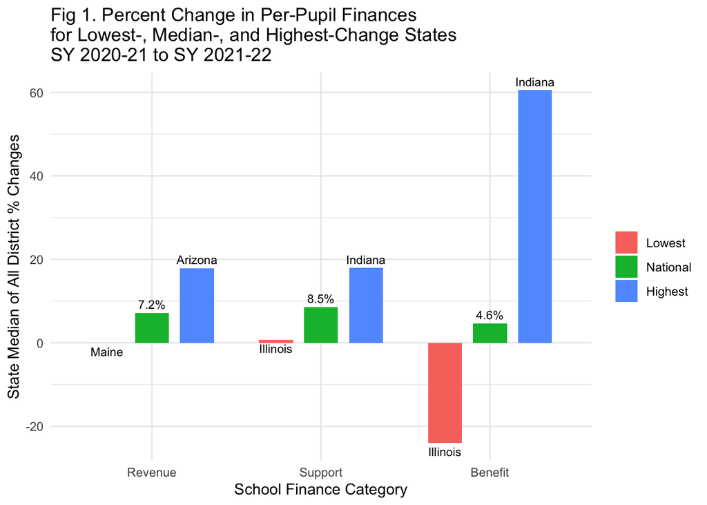

```r
position <- position_dodge(width = 0.8)

med_pct_comparisons |>
  mutate(metric = factor(metric,
                         levels = c("med_rev_pct","med_supp_pct","med_ben_pct"),
                         labels = c("Revenue","Support","Benefit"))) |>
  pivot_longer(c(lowest_pct, national_med, highest_pct),
               names_to="type", values_to="pct") |>
  mutate(
    type = factor(type,
                  levels = c("lowest_pct","national_med","highest_pct"),
                  labels = c("Lowest","National","Highest")),
    label = case_when(
      type=="Lowest"  ~ lowest_state,
      type=="Highest" ~ highest_state,
      TRUE ~ sprintf("%.1f%%", pct)
                  ),
    vjust_value = ifelse(type=="Lowest", 1.5, -0.5)
    ) |>
  ggplot(aes(metric, pct, fill = type)) +
    geom_col(position = position, width = 0.6) +
    geom_text(aes(label=label, vjust=vjust_value),
              position = position, size=3) +
    labs(x="School Finance Category",
         y="State Median of All District % Changes",
         title="Fig 1. Percent Change in Per-Pupil Finances\nfor Lowest-, Median-, and Highest-Change States \nSY 2020-21 to SY 2021-22") +
  theme_minimal()+
  theme(legend.title = element_blank()
        )
```

## Distribution inequity

### Data processing

```r
state_9010_tile <- clean_nces |>
  filter(state != "Hawaii") |>
  group_by(state) |>
  summarise(
    Revenue = {p <- quantile(rev_21_22,  c(.1, .9), na.rm = TRUE); p[2]/p[1]},
    Support = {p <- quantile(supp_21_22, c(.1, .9), na.rm = TRUE); p[2]/p[1]},
    Benefit = {p <- quantile(ben_21_22,  c(.1, .9), na.rm = TRUE); p[2]/p[1]},
    .groups = "drop"
  ) |>
  pivot_longer(-state, names_to = "metric", values_to = "ratio") |>
  filter(is.finite(ratio)) |>
  group_by(metric) |>
  mutate(med_all = median(ratio, na.rm = TRUE)) |>
  summarise(
    lowest_state = state[which.min(ratio)],
    lowest_value = min(ratio, na.rm = TRUE),
    median_state = state[which.min(abs(ratio - med_all))],
    median_value = med_all[1],
    highest_state = state[which.max(ratio)],
    highest_value = max(ratio, na.rm = TRUE),
    .groups = "drop"
  )

tile_comparisons <- state_9010_tile |>
  # bring lowest/median/highest into rows in one go
  pivot_longer(
    cols = -metric,
    names_to = c("type", ".value"),
    names_pattern = "(lowest|median|highest)_(state|value)"
  ) |>
  mutate(
    # rename value → ratio, and clean up type & metric
    ratio = value,
    type = factor(type,
                    levels = c("lowest","median","highest"),
                    labels = c("Lowest","Median","Highest")),
    metric = factor(metric,
                    levels = c("Revenue","Support","Benefit"))
  ) |>
  select(metric, type, state, ratio)
```

### Graphing

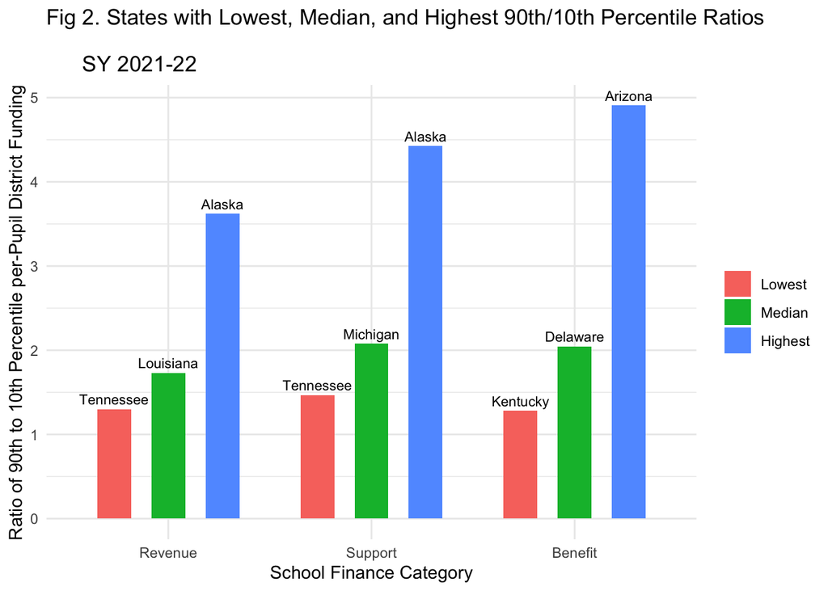

```r
tile_comparisons |>
  ggplot(aes(metric, ratio, fill = type)) +
    geom_col(position = position_dodge(0.8), width = 0.5) +
    geom_text(aes(label = state,
                  vjust = if_else(type == "Lowest",  -0.5,
                          if_else(type == "Highest", -0.5, -0.5))),
              position = position_dodge(0.8),
              size = 3) +
    labs(
      title = "Fig 2. States with Lowest, Median, and Highest 90th/10th Percentile Ratios\n
      SY 2021-22",
      x = "School Finance Category",
      y = "Ratio of 90th to 10th Percentile per-Pupil District Funding"
    ) +
    theme_minimal() +
    theme(legend.title = element_blank()
          )
```

## Summary

Figure 1 shows disparities in states’ per-pupil education finances from School Year 2020–21 to 2021–22. The U.S. as a whole experienced increases in revenue and spending (i.e., support and benefit expenditure), but the percent change varied by state. For instance, Indiana had the largest increase in benefit spending at over 60%, while Illinois experienced a decrease of more than 20%. These differences reflect unequal state-level responses in the wake of the pandemic and point to a pattern of school finance inequity across the country.

Figure 2 highlights the ratio of per-pupil funding between the 90th and 10th percentile districts within each state. Arizona, for example, had a benefit ratio of nearly 5 to 1, indicating a wide spending gap between its highest- and lowest-funded districts. In contrast, Tennessee and Kentucky had much lower ratios, suggesting more equitable distribution. These figures show that in some states, a student’s access to educational resources is tied closely to district wealth. Together, the two graphs reveal inequities in public school funding between states and within them.